# 红酒数据集探索性数据分析

# 双变量绘图选择

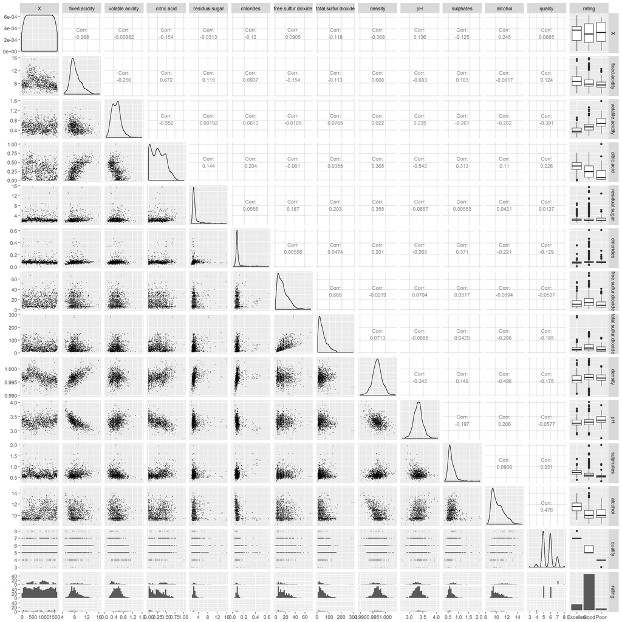

从散点图矩阵可以看出：

1. 影响红酒质量的主要因素有: 挥发酸,柠檬酸,硫化物,酒精度.
2. 其他两两高度相关的因素有(这里指相关系数的绝对值大于或者接近于0.5的因素): 柠檬酸和固定酸 柠檬酸和挥发酸 柠檬酸和PH值 固定酸和密度 固定酸和pH值 总二氧化硫和游离二氧化硫 酒精度和密度

## 质量与挥发酸的关系

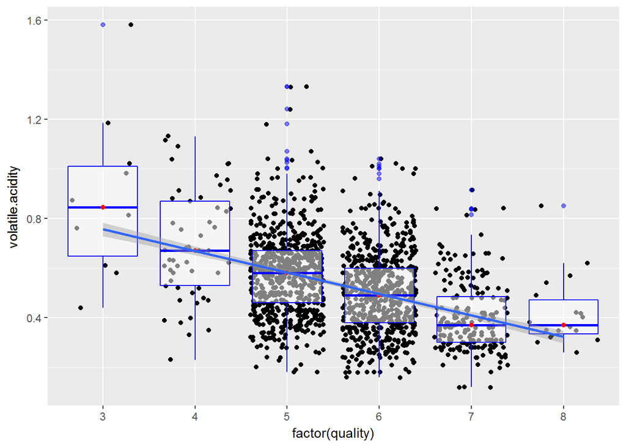

除了质量评分为8的红酒，质量与挥发酸的含量中位数呈负相关关系。

## 质量与柠檬酸的关系

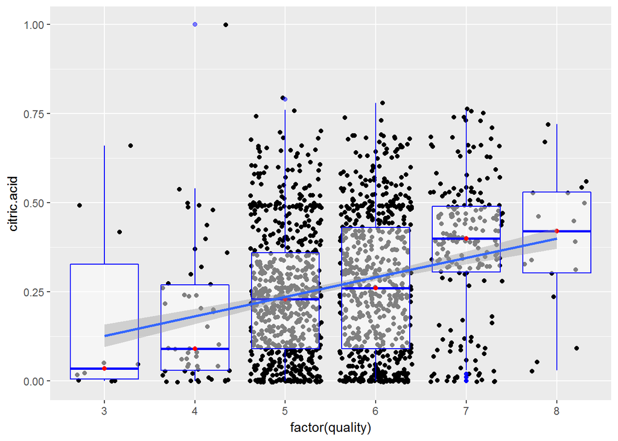

质量与柠檬酸的含量中位数呈正相关关系。

## 质量和硫化物的关系

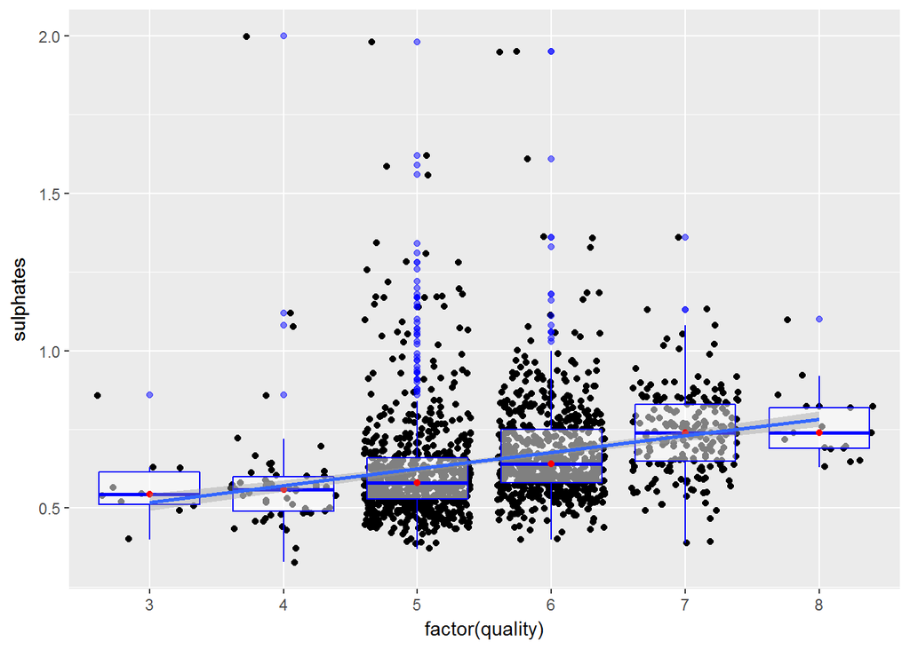

质量与硫化物含量的中位数呈正相关关系。

## 质量和酒精度数的关系

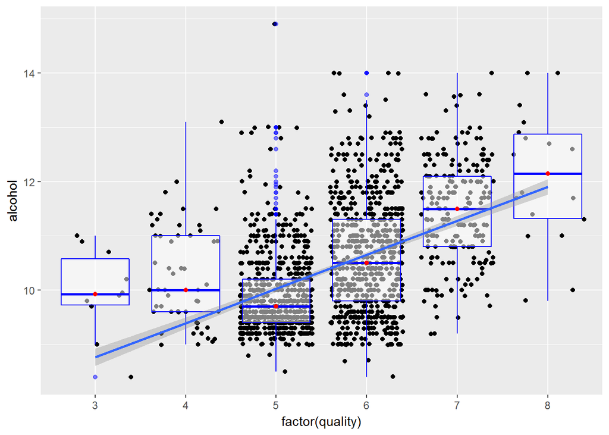

红酒质量和酒精浓度不是严格的线性相关,质量评分5分以上的红酒，其质量和酒精度呈正相关。

## 其他相关关系:

## 柠檬酸和固定酸的相关关系:

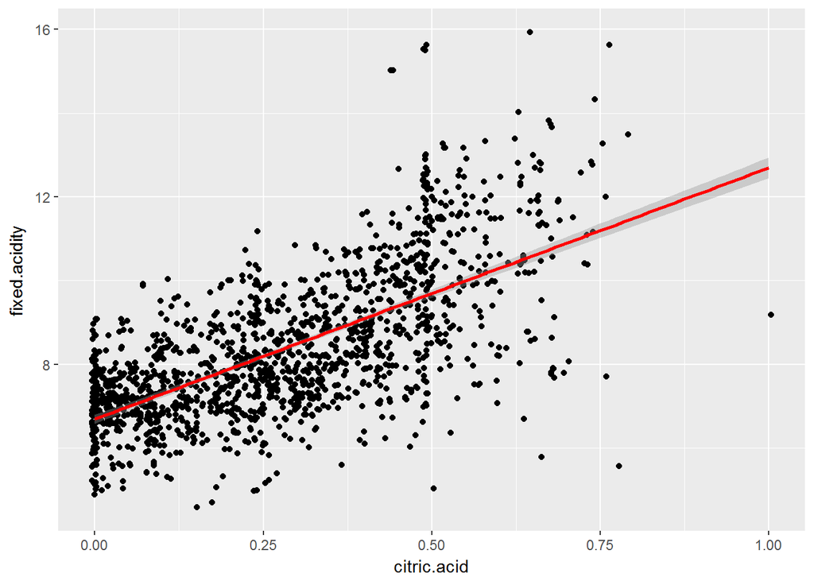

柠檬酸和固定酸呈正相关。

## 柠檬酸和挥发酸的相关关系:

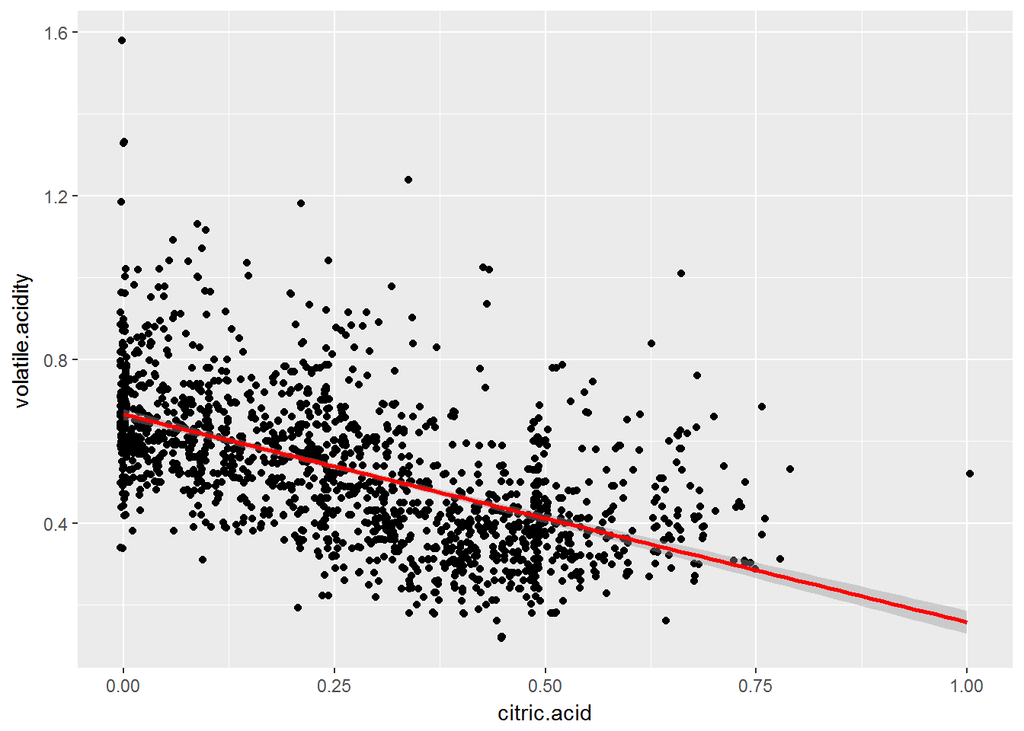

柠檬酸和挥发酸呈负相关。

## 柠檬酸和PH值的相关关系:

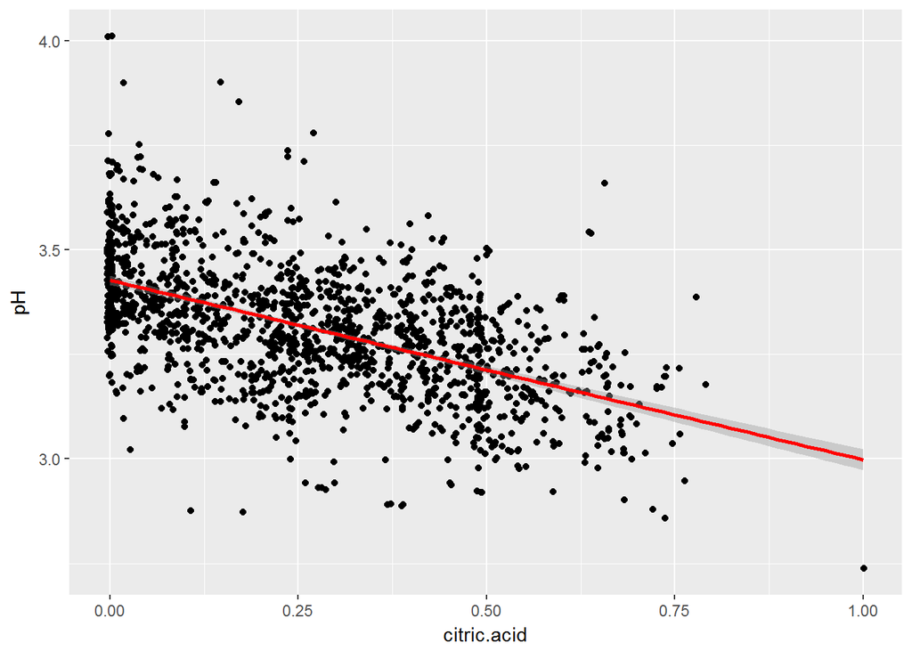

柠檬酸和PH值呈负相关。

## 固定酸和密度的相关关系:

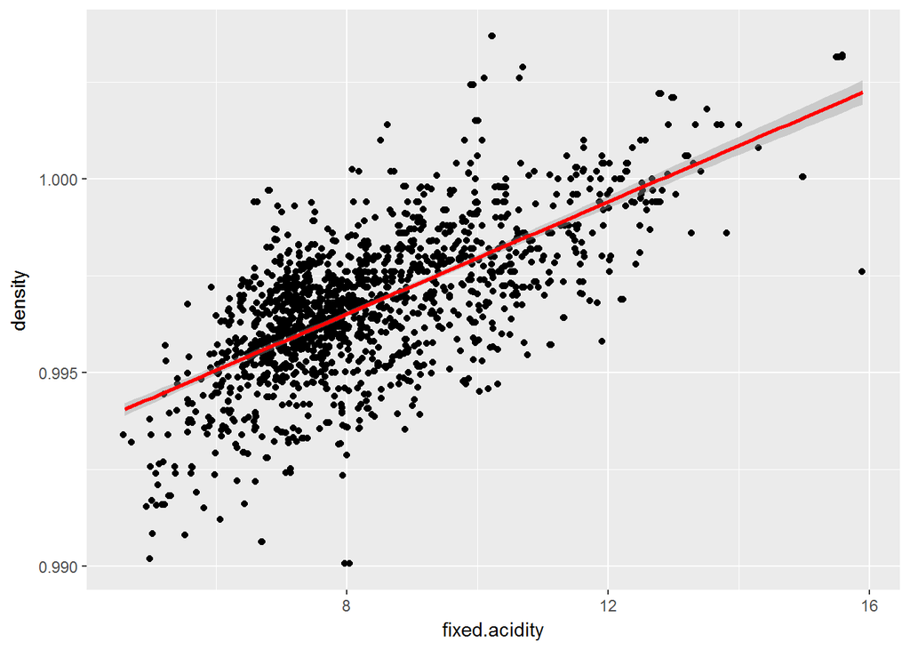

固定酸和密度呈正相关。

## 固定酸和PH值的相关关系:

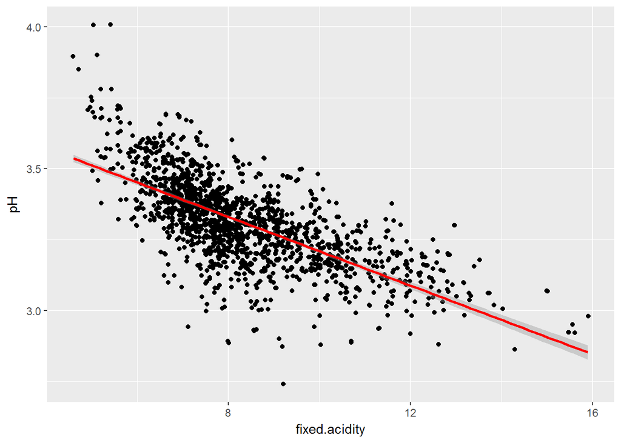

固定酸和ph值呈负相关。

## 总二氧化硫和游离二氧化硫的相关关系:

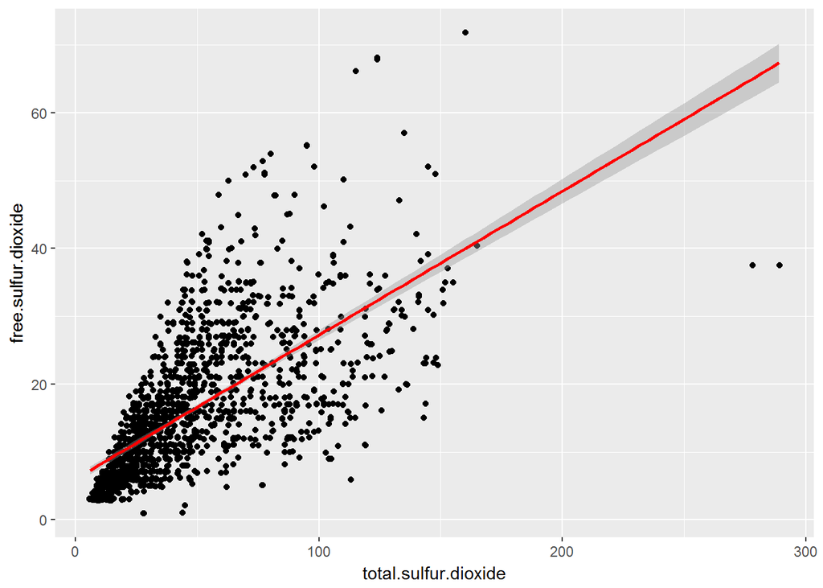

总二氧化硫和游离二氧化硫呈正相关。

## 酒精和密度的相关关系:

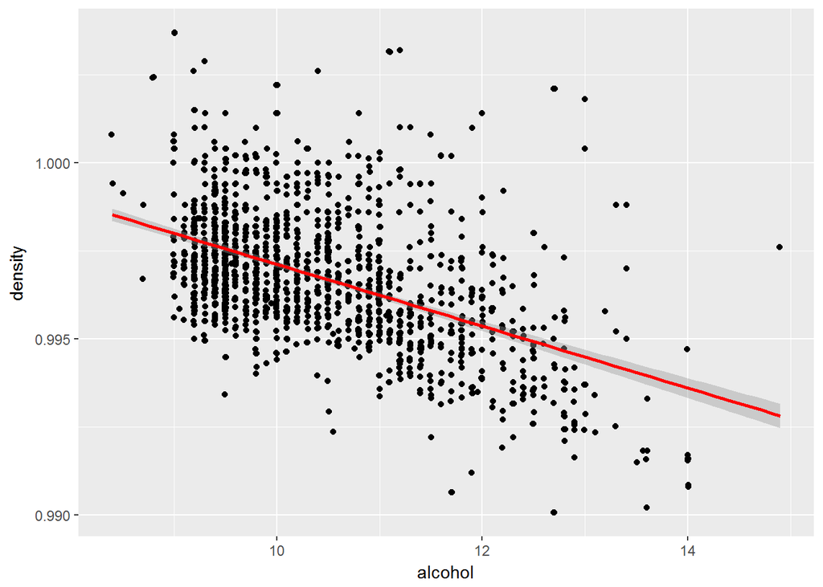

酒精和密度呈负相关。

# 双变量分析

### 探讨你在这部分探究中观察到的一些关系。这些感兴趣的特性与数据集内其他特性有什么区别？

根据散点图矩阵图，观察到红酒质量与4个因素相关性比较大，分别是酒精浓度、挥发酸、硫化物和柠檬酸，它们的相关系数分别是0.48,-0.39,0.25,0.23。

```
##
##  Pearson's product-moment correlation
##
## data:  wine$quality and wine$alcohol
## t = 21.639, df = 1597, p-value < 2.2e-16
## alternative hypothesis: true correlation is not equal to 0
## 95 percent confidence interval:
##  0.4373540 0.5132081
## sample estimates:
##       cor
## 0.4761663
```

```
##
##  Pearson's product-moment correlation
##
## data:  wine$quality and wine$volatile.acidity
## t = -16.954, df = 1597, p-value < 2.2e-16
## alternative hypothesis: true correlation is not equal to 0
## 95 percent confidence interval:
##  -0.4313210 -0.3482032
## sample estimates:
##        cor
## -0.3905578
```

```
##
##  Pearson's product-moment correlation
##
## data:  wine$quality and wine$sulphates
## t = 10.38, df = 1597, p-value < 2.2e-16
## alternative hypothesis: true correlation is not equal to 0
## 95 percent confidence interval:
##  0.2049011 0.2967610
## sample estimates:
##       cor
## 0.2513971
```

```
##
##  Pearson's product-moment correlation
##
## data:  wine$quality and wine$citric.acid
## t = 9.2875, df = 1597, p-value < 2.2e-16
## alternative hypothesis: true correlation is not equal to 0
## 95 percent confidence interval:
##  0.1793415 0.2723711
## sample estimates:
##       cor
## 0.2263725
```

其中： 质量和酒精不是严格的线性相关,质量评分5分之后与酒精呈正相关。 质量和挥发酸不是严格的线性相关, 除了质量评分8分外呈负相关。 质量与硫化物呈正相关。 质量与柠檬酸呈正相关。

### 你是否观察到主要特性与其他特性之间的有趣关系？

柠檬酸和固定酸呈正相关。 柠檬酸和挥发酸呈负相关。 柠檬酸和pH值呈负相关。 密度和固定酸呈正相关。 pH值和固定酸呈负相关。 总二氧化硫和游离二氧化硫呈正相关。 酒精度和密度呈负相关。

### 你发现最强的关系是什么？

最强相关的两个因素是固定酸和pH值,这两者的皮尔森相关系数约为-0.68.

```
##
##  Pearson's product-moment correlation
##
## data:  wine$pH and wine$fixed.acidity
## t = -37.366, df = 1597, p-value < 2.2e-16
## alternative hypothesis: true correlation is not equal to 0
## 95 percent confidence interval:
##  -0.7082857 -0.6559174
## sample estimates:
##        cor
## -0.6829782
```

# 多变量绘图选择

以上找到与红酒质量相关性较大的四个因素相关性不是十分强，因此我们在多变量分析中继续寻找。

## 固定酸和挥发酸在不同质量下的相关关系:

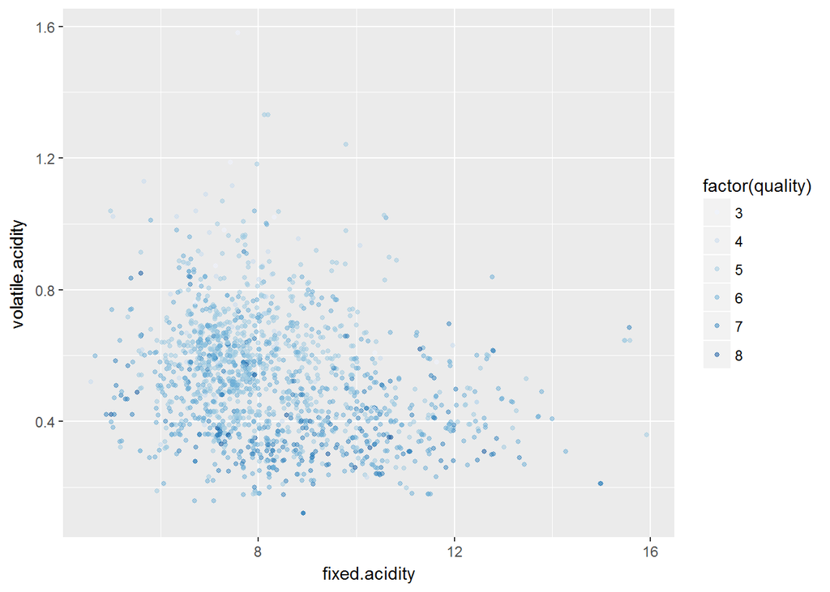

由图看出固定酸与挥发酸呈负相关，且质量较高的红酒分布在挥发酸较低的地方。

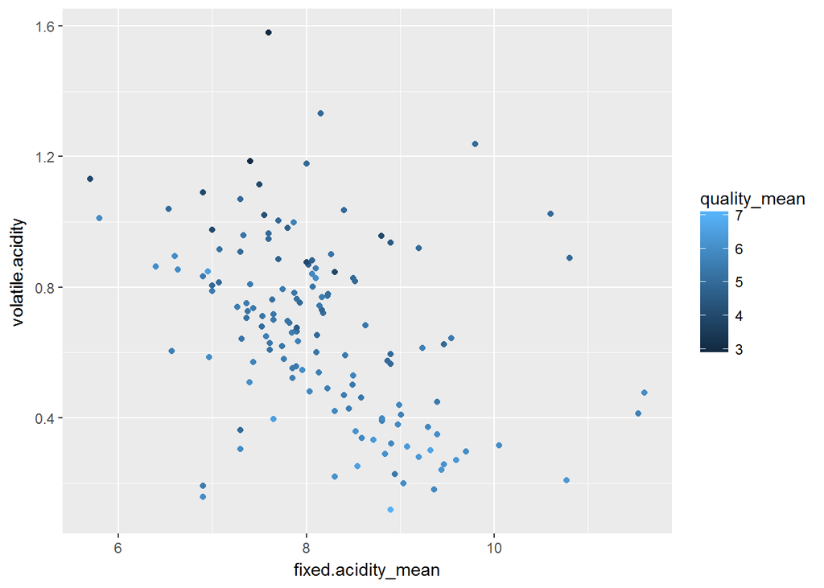

对挥发酸为分组条件，取固定酸均值处理之后我们从图中可以更为明显的看到，质量较好的红酒主要分布在挥发性酸较低和固定酸较高的区域。而质量较差的红酒则更多集中在固定酸较低和挥发性酸较高的区域。

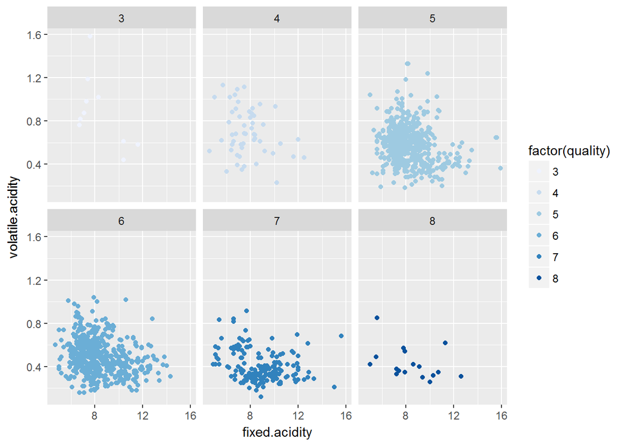

几乎是质量越好的红酒，含有的挥发性酸越较少。